# May institute Data visualization module: Hands-on 2

## 2.2 Mapping variable values to colors

We can also map variables to colors by putting it inside an `aes()` statement.

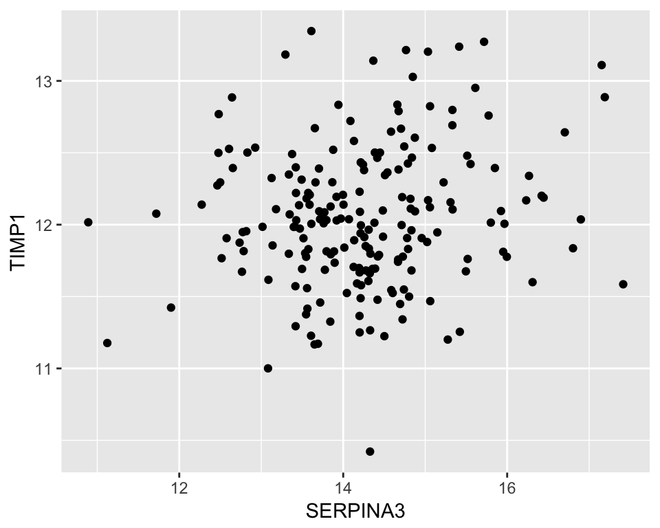

```r
# Default: dark color
g2 <- ggplot(CRC, aes(x = SERPINA3, y = TIMP1))
g2 + geom_point()
```

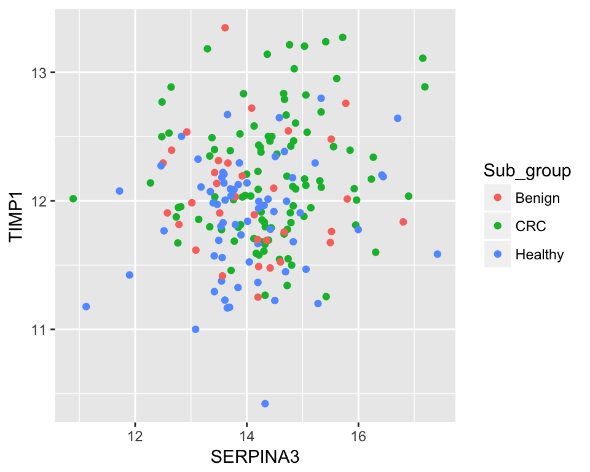

```r
# Make the color conditional on 'Sub_group'
g2 + geom_point(mapping = aes(color = Sub_group))
```

It is also possible to change manually the colors using the functions:

- scale_color_grey() : to use grey color palettes
- scale_color_manual() : to use custom colors
- scale_color_brewer() : to use color palettes from RColorBrewer package

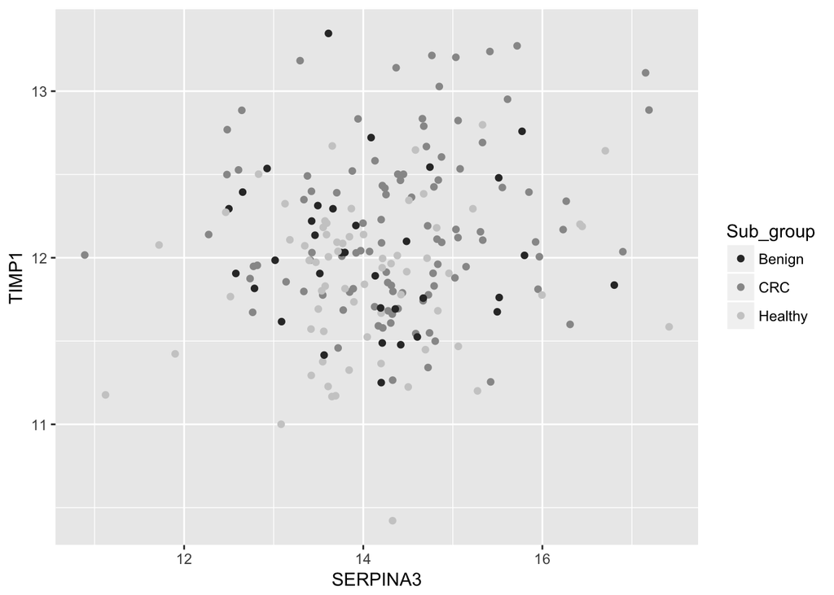

```r
# Sequential grey colour scales
g2 + geom_point(mapping = aes(color = Sub_group)) +
  scale_color_grey()
```

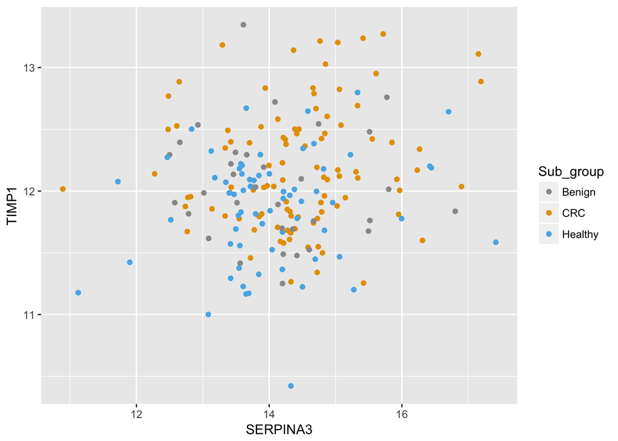

```r
# Change the colour manually
g2 + geom_point(mapping = aes(color = Sub_group)) +
  scale_color_manual(values=c("#999999", "#E69F00", "#56B4E9"))
```

```r
# RColorBrewer is a good R package for color palettes.
# Its function has an argument for the number of colors and the color palette
# install.packages("RColorBrewer")
library(RColorBrewer)
brewer.pal(4, "Set1")
```

```
## [1] "#E41A1C" "#377EB8" "#4DAF4A" "#984EA3"
```

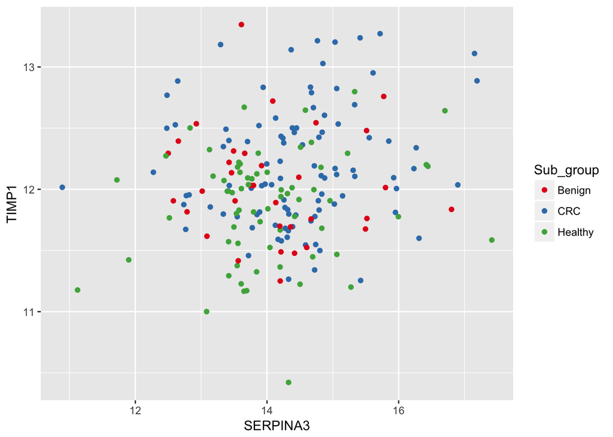

```r
g2 + geom_point(mapping = aes(color = Sub_group)) +
  scale_color_manual(values=brewer.pal(3, "Set1"))
```

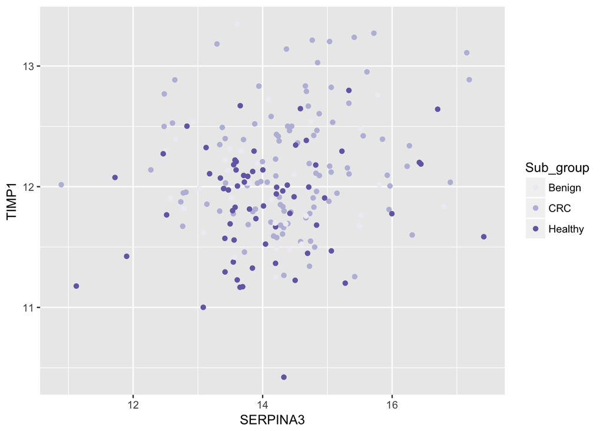

```r
# Sequential purple colour scales
g2 + geom_point(mapping = aes(color = Sub_group)) +
  scale_color_brewer(palette = "Purples")
```

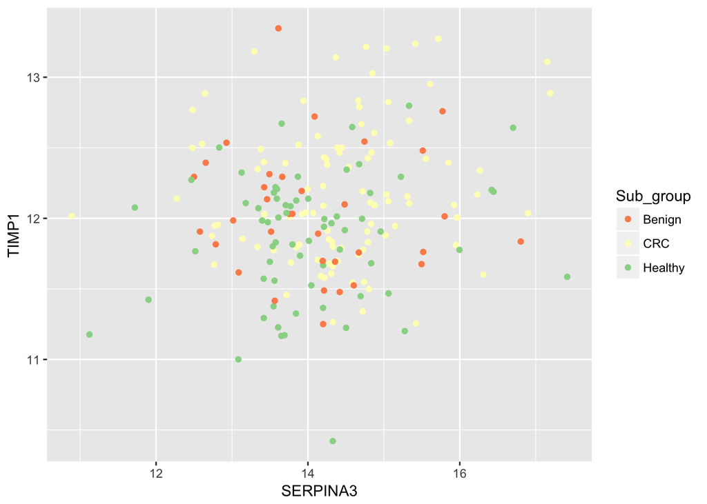

```r
# Diverging Spectral color
g2 + geom_point(mapping = aes(color = Sub_group)) +
  scale_color_brewer(palette = "Spectral")
```

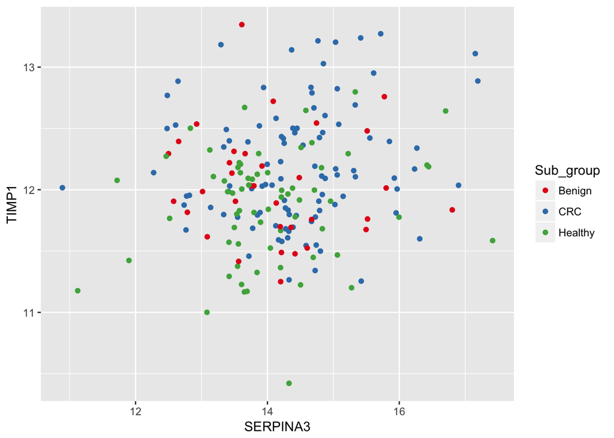

```r
# Qualitative Set1 color
g2 + geom_point(mapping = aes(color = Sub_group)) +
  scale_color_brewer(palette = "Set1")
```

> **Challenge** Plot the scatter plot of the abundance of protein AFM and AHSG and specify the color by gender using “Paired” palette.

$~$

$~$ $~$

$~$ $~$

$~$ $~$

$~$ $~$

$~$ $~$

$~$

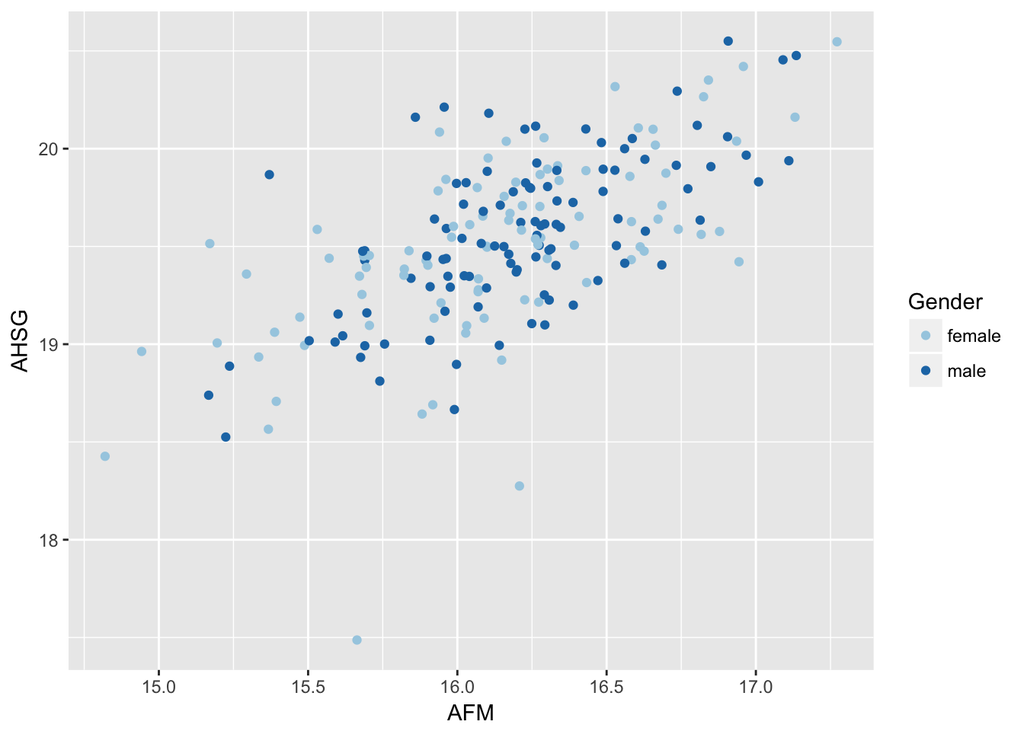

```r
ggplot(CRC, aes(x = AFM, y = AHSG))+
  geom_point(mapping = aes(color = Gender))+
  scale_color_brewer(palette = "Paired")
```